# 10.29.2025 Homestead Migrant Children

The shelter was operated by Comprehensive Health Services under a [$220 million contract](https://www.npr.org/2019/02/13/694138106/inside-the-largest-and-most-controversial-shelter-for-migrant-children-in-the-u-) with Health and Human Services. It was one of the first for-profit migrant shelters in America. Despite losing nearly [$1.2 million](https://www.npr.org/2019/02/13/694138106/inside-the-largest-and-most-controversial-shelter-for-migrant-children-in-the-u-) daily, the government contract paid a [fixed](https://www.americanprogress.org/article/how-for-profit-companies-are-driving-immigration-detention-policies/?utm_source=chatgpt.com) and daily rate, as long as beds stayed full. Beds remained full for an average of 59 days, on par with the national rate of 60 days.

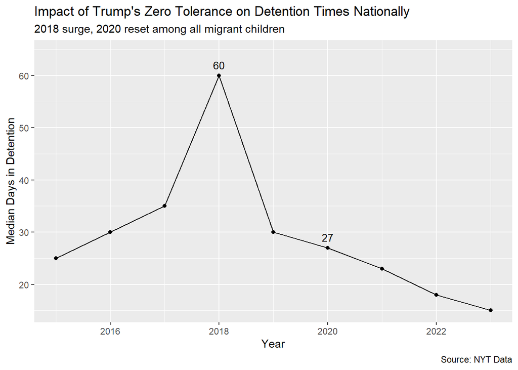

```r
nat_year <- national %>%
  mutate(year = year(childs_date_of_entry)) %>%
  group_by(year) %>%
  summarise(days = median(days_in, na.rm = TRUE), .groups = "drop")

nat_year %>%
  ggplot(aes(x = year, y = days)) +
  geom_line() +
  geom_point() +
  geom_text(aes(label = ifelse(year %in% c(2018, 2020), round(days), "")),
            vjust = -0.8, size = 3.5) +
  scale_y_continuous(expand = expansion(mult = c(0.05, 0.15))) +
  labs(
    title = "Impact of Trump's Zero Tolerance on Detention Times Nationally",
    subtitle = "2018 surge, 2020 reset among all migrant children",
    caption = "Source: NYT Data",
    x = "Year",
    y = "Median Days in Detention"
  )
```

```r
ggsave("nat_year.png", width = 8, height = 5, dpi = 300)
```

**Guatemalan Children - Nationally Line Chart**

After the shelter’s closing in 2019, the time children spent in migrant shelters drastically decreased – 23 days in comparison to the previous 59. Initially these findings were attributed to the detention center, but after further analysis the trend in Homestead closely follows the results for children of all ethnicities nationwide.

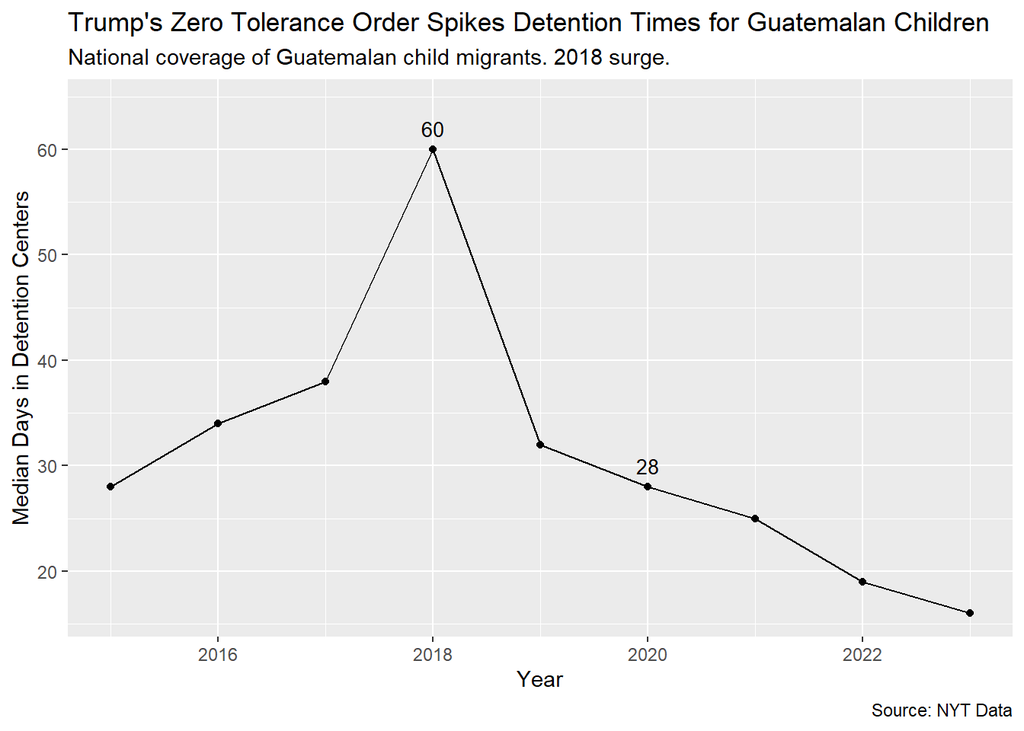

```r
guat_year <- guatemala %>%
  mutate(year = year(childs_date_of_entry)) %>%
  group_by(year) %>%
  summarise(days = median(days_in, na.rm = TRUE), .groups = "drop")

guat_year %>%
  ggplot(aes(x = as.numeric(year), y = as.numeric(days))) +
  geom_line() +
  geom_point() +
  geom_text(
    aes(label = ifelse(year %in% c(2018, 2020), days, "")),
    vjust = -0.8, size = 3.5
  ) +
  scale_y_continuous(expand = expansion(mult = c(0.05, 0.15))) +
  labs(
    title = "Trump's Zero Tolerance Order Spikes Detention Times for Guatemalan Children",
    subtitle = "National coverage of Guatemalan child migrants. 2018 surge.",
    caption = "Source: NYT Data",
    x = "Year",
    y = "Median Days in Detention Centers"
  )
```

```r
ggsave("guat_year.png", width = 8, height = 5, dpi = 300)
```

**Guatemalan Children - Homestead, FL Line Chart**